# Problem Set 4

## 3. Prediction

Let's use our fitted model to make predictions about housing prices. Since the focus is now on prediction rather than the interpretation of the coefficients, first standardize your features before proceeding.

### 3.1 Cross-Validation

Unless you were careful above, you probably overfit your data again. Let's fix that in one of two ways. If you're feeling confident, use k-fold cross-validation to re-fit the multiple regression from 2.3 above, and report your estimated coefficients (there should be three, corresponding to the intercept and the two coefficients for CRIM and RM). Or if you want to do the quick and dirty version, randomly divide your data into a training set (66%) and testing set (34%) and use the training set to re-fit the regression from 2.3 above.

#### 10-fold Cross Validation : MEDV vs ['RM']

```python
num_splits = 10
kf = KFold(n_splits=num_splits, shuffle=False, random_state=1)
kf.get_n_splits(boston_df)
```

```
10
```

```python
coefs1 = []
features=['RM']
X3_df = boston_df[features] #Dataframe
print('Cross-validating Model: MEDV vs ', features, '\n----------------------')

i=0
for train_index, test_index in kf.split(X3_df):
    print('Estimating coefficients for Training Split # : ', i+1)
    #print("TRAIN:", train_index, "TEST:", test_index)                #ndarray type

    #Fetch data into training set
    X3_train = X3_df.ix[train_index]   #Fetch subset of df rows
    y_train  = y[train_index]          #Fetch subset of Series rows

    #Prepare TRAIN data: Choose features, Standardize X, Add Intercept to X, convert to Array
    x_train_norm_arr = prepare_df_for_ols(X3_train, feature_list=features, add_intercept=True, standardize_features=True)
    y_train_arr = np.array(y_train)

    #Estimate parameters using Multivariate Gradient Descent
    res = multivariate_ols(x_train_norm_arr, y_train_arr, R=0.01,   MaxIterations=10000,  verbose=False)
    theta, ttaken, num_iter, convergence, cost_history, theta_history = res
    print('Estimated Coefficients :', theta,'\n')

    coefs1.append(theta)
    i+=1
```

```
Cross-validating Model: MEDV vs  ['RM']
----------------------
Estimating coefficients for Training Split # :  1
Estimated Coefficients : [ 22.66705077   6.50324666]

Estimating coefficients for Training Split # :  2
Estimated Coefficients : [ 22.23771876   6.49597983]

Estimating coefficients for Training Split # :  3
Estimated Coefficients : [ 22.93611887   6.55573644]

Estimating coefficients for Training Split # :  4
Estimated Coefficients : [ 21.46208844   5.56437983]

Estimating coefficients for Training Split # :  5
Estimated Coefficients : [ 21.85415606   5.97722791]

Estimating coefficients for Training Split # :  6
Estimated Coefficients : [ 21.44261485   5.5082732 ]

Estimating coefficients for Training Split # :  7
Estimated Coefficients : [ 22.5133927   6.598502 ]

Estimating coefficients for Training Split # :  8
Estimated Coefficients : [ 22.99684487   6.88394251]

Estimating coefficients for Training Split # :  9
Estimated Coefficients : [ 23.41560692   6.71057044]

Estimating coefficients for Training Split # :  10
Estimated Coefficients : [ 22.84607325   6.57783642]
```

```python
coefs1 = np.array(coefs1)
print('Calculated coefficients for Bivariate OLS using CV :\n', coefs1)
```

```
Calculated coefficients for Bivariate OLS using CV :
 [[ 22.66705077   6.50324666]
 [ 22.23771876   6.49597983]
 [ 22.93611887   6.55573644]
 [ 21.46208844   5.56437983]
 [ 21.85415606   5.97722791]
 [ 21.44261485   5.5082732 ]
 [ 22.5133927    6.598502  ]
 [ 22.99684487   6.88394251]
 [ 23.41560692   6.71057044]
 [ 22.84607325   6.57783642]]
```

#### 10-fold Cross Validation : MEDV vs ['RM', 'CRIM']

```python
num_splits = 10
kf = KFold(n_splits=num_splits, shuffle=False, random_state=1)
kf.get_n_splits(boston_df)
```

```
10
```

```python
coefs2 = []
features=['RM', 'CRIM']
X3_df = boston_df[features] #Dataframe
print('Cross-validating Model: MEDV vs ', features, '\n----------------------')

i=0
for train_index, test_index in kf.split(X3_df):
    print('Estimating coefficients for Training Split # : ', i+1)
    #print("TRAIN:", train_index, "TEST:", test_index)                #ndarray type

    #Fetch data into training set
    X3_train = X3_df.ix[train_index]   #Fetch subset of df rows
    y_train  = y[train_index]          #Fetch subset of Series rows

    #Prepare TRAIN data: Choose features, Standardize X, Add Intercept to X, convert to Array
    x_train_norm_arr = prepare_df_for_ols(X3_train, feature_list=['RM', 'CRIM'], add_intercept=True, standardize_features=True)
    y_train_arr = np.array(y_train)

    #Estimate parameters using Multivariate Gradient Descent
    res = multivariate_ols(x_train_norm_arr, y_train_arr, R=0.01,   MaxIterations=10000,  verbose=False)
    theta, ttaken, num_iter, convergence, cost_history, theta_history = res
    print('Estimated Coefficients :', theta,'\n')

    coefs2.append(theta)
    i+=1
```

```
Cross-validating Model: MEDV vs  ['RM', 'CRIM']
----------------------
Estimating coefficients for Training Split # :  1
Estimated Coefficients : [ 22.66800224   5.92424226  -2.44074315]

Estimating coefficients for Training Split # :  2
Estimated Coefficients : [ 22.23867125   5.97220126  -2.38516284]

Estimating coefficients for Training Split # :  3
Estimated Coefficients : [ 22.93801553   5.94917575  -2.47509783]

Estimating coefficients for Training Split # :  4
Estimated Coefficients : [ 21.46208844   5.07566341  -2.31270931]

Estimating coefficients for Training Split # :  5
Estimated Coefficients : [ 21.85415606   5.46139988  -2.33805823]

Estimating coefficients for Training Split # :  6
Estimated Coefficients : [ 21.44164892   5.03377867  -2.34548907]

Estimating coefficients for Training Split # :  7
Estimated Coefficients : [ 22.51433772   6.04504055  -2.42890709]

Estimating coefficients for Training Split # :  8
Estimated Coefficients : [ 22.99965466   6.53969103  -1.67096968]

Estimating coefficients for Training Split # :  9
Estimated Coefficients : [ 23.41750455   6.38838881  -1.75603575]

Estimating coefficients for Training Split # :  10
Estimated Coefficients : [ 22.8470226    6.03877827  -2.3778887 ]
```

```python
coefs2 = np.array(coefs2)
print('Calculated coefficients for Multivariate OLS using CV :\n', coefs2)
```

```
Calculated coefficients for Multivariate OLS using CV :
 [[ 22.66800224   5.92424226  -2.44074315]
 [ 22.23867125   5.97220126  -2.38516284]
 [ 22.93801553   5.94917575  -2.47509783]
 [ 21.46208844   5.07566341  -2.31270931]
 [ 21.85415606   5.46139988  -2.33805823]
 [ 21.44164892   5.03377867  -2.34548907]
 [ 22.51433772   6.04504055  -2.42890709]
 [ 22.99965466   6.53969103  -1.67096968]
 [ 23.41750455   6.38838881  -1.75603575]
 [ 22.8470226    6.03877827  -2.3778887 ]]
```

### 3.2 Predicted values and RMSE

Let's figure out how accurate this predictive model turned out to be. Compute the RMSE on your test cases, i.e. take the model parameters that you found above and compare the actual to the predicted values for just the test instances. If you did this the k-fold way above, this will be the average RMSE across the k test sets. If you did this the quick and dirty way above, this will just be the RMSE on your single test set.

What is your test RMSE? How does it compare to the performance of your nearest neighbor algorithm from the last problem set? How does it compare to RMSE from a simpler model where number of rooms is the only explanatory variable?

#### *Define Helper* : Compute RMSE

```python
#Use Kfold to fit the model, and choose the coefficients
def compute_rmse(predictions , yvalues):
    if(len(predictions) !=len(yvalues)):
        print('Lists of unequal lengths')
        return -1

    sum_ee=0
    for (pred, y) in zip(predictions , yvalues):
        e = y - pred
        e2= e*e
        sum_ee = sum_ee+ e2

    mse=sum_ee/len(yvalues)
    rmse = np.sqrt(mse)
    return rmse
```

#### Find mean test RMSE from Cross-validation (MEDV vs RM)

```python
#Predict y_hat using the various estimated parameters of CV (coefs)
#Find error in each model
#Compute RMSE

rmse_list = []
feature_cols = ['RM']
X3_df = boston_df[feature_cols] #Dataframe
print('Features  :', feature_cols, '\n')

i=0
for train_index, test_index in kf.split(X3_df):
    print('Predicting for Test Split # : ', i+1)
    #print("TRAIN:", train_index, "TEST:", test_index)                #ndarray type

    #Fetch data into test set
    X3_test = X3_df.ix[test_index]   #Fetch subset of df rows
    y_test  = y[test_index]          #Fetch subset of Series rows

    #Prepare TEST data: Choose features, Standardize X, Add Intercept to X, convert to Array
    x_test_norm_arr = prepare_df_for_ols(X3_test, feature_list=feature_cols, add_intercept=True, standardize_features=True)
    y_test_arr = np.array(y_test)

    #Use coefficient estimates to make TEST predictions
    thetas = coefs1[i]
    preds = x_test_norm_arr.dot(thetas)

    #Calculate prediction error
    rmse = compute_rmse(preds, y_test_arr)
    rmse_list.append(rmse)
    i+=1

print('\nLast Split in detail')
print('x      : ', x_test_norm_arr.shape)  # (51 or 50,3)
print('thetas : ', thetas.shape)           # (3,)
print('y      : ', y_test_arr.shape)       # (51 or 50,)
print('preds  : ', preds.shape)           # (51 or 50,)

#Calculate Mean RMSE
rmse_list = np.array(rmse_list)
print('\nTest RMSE across', num_splits,'Cross-Validation splits:\n', rmse_list)
print('\nMean Test RMSE of', num_splits , 'Cross-Validation splits :\n', np.mean(rmse_list) )
```

```
Features  : ['RM']

Predicting for Test Split # :  1
Predicting for Test Split # :  2
Predicting for Test Split # :  3
Predicting for Test Split # :  4
Predicting for Test Split # :  5
Predicting for Test Split # :  6
Predicting for Test Split # :  7
Predicting for Test Split # :  8
Predicting for Test Split # :  9
Predicting for Test Split # :  10

Last Split in detail
x      :  (50, 2)
thetas :  (2,)
y      :  (50,)
preds  :  (50,)

Test RMSE across 10 Cross-Validation splits:
 [  4.8092079    3.46529596   7.27373423  11.16985077   6.98482119
  10.78106991   3.68031469  14.35472475  12.4371186    6.80411118]

Mean Test RMSE of 10 Cross-Validation splits :
 8.17602491663
```

#### Find mean test RMSE from Cross-validation (MEDV vs RM, CRIM)

```python
#Predict y_hat using the various estimated parameters of CV (coefs)
# Find error in each model
#Compute RMSE

rmse_list = []
feature_cols = ['RM', 'CRIM']
X3_df = boston_df[feature_cols] #Dataframe
print('Features  :', feature_cols,'\n')

i=0
for train_index, test_index in kf.split(X3_df):
    print('Predicting for Test Split # : ', i+1)
    #print("TRAIN:", train_index, "TEST:", test_index)                #ndarray type

    #Fetch data into test set
    X3_test = X3_df.ix[test_index]   #Fetch subset of df rows
    y_test  = y[test_index]          #Fetch subset of Series rows

    #Prepare TEST data: Choose features, Standardize X, Add Intercept to X, convert to Array
    x_test_norm_arr = prepare_df_for_ols(X3_test, feature_list=feature_cols, add_intercept=True, standardize_features=True)
    y_test_arr = np.array(y_test)

    #Use coefficient estimates to make TEST predictions
    thetas = coefs2[i]
    preds = x_test_norm_arr.dot(thetas)

    #Calculate prediction error
    rmse = compute_rmse(preds, y_test_arr)
    rmse_list.append(rmse)
    i+=1

print('\nLast Split in detail')
print('x      : ', x_test_norm_arr.shape)  # (51 or 50,3)
print('thetas : ', thetas.shape)           # (3,)
print('y      : ', y_test_arr.shape)       # (51 or 50,)
print('preds  : ', preds.shape)           # (51 or 50,)

#Calculate Mean RMSE
rmse_list = np.array(rmse_list)
print('\nTest RMSE across', num_splits,'Cross-Validation splits:\n', rmse_list)
print('\nMean Test RMSE of', num_splits , 'Cross-Validation splits :\n', np.mean(rmse_list) )
```

```
Features  : ['RM', 'CRIM']

Predicting for Test Split # :  1
Predicting for Test Split # :  2
Predicting for Test Split # :  3
Predicting for Test Split # :  4
Predicting for Test Split # :  5
Predicting for Test Split # :  6
Predicting for Test Split # :  7
Predicting for Test Split # :  8
Predicting for Test Split # :  9
Predicting for Test Split # :  10

Last Split in detail
x      :  (50, 3)
thetas :  (3,)
y      :  (50,)
preds  :  (50,)

Test RMSE across 10 Cross-Validation splits:
 [  4.28613042   3.97258148   7.97132401  11.19843003   7.78456061
  11.37696348   4.9785493   13.77399116  12.61672667   6.73012843]

Mean Test RMSE of 10 Cross-Validation splits :
 8.4689385607
```

#### *Compare* : RMSE from Multivariate OLS with other values

What is your test RMSE? How does it compare to the performance of your nearest neighbor algorithm from the last problem set? How does it compare to RMSE from a simpler model where number of rooms is the only explanatory variable?

Target = 'MEDV' Features = ['RM', 'CRIM']

**Cross-validated test RMSE** The RMSE calculated above for multivariate gradient descent is below, along with other RMSE for comparison. No shuffle of data was done for Cross-validation.

> Multivariate OLS Gradient Descent (10-fold CV) = 8.469

> Bivariate OLS Gradient Descent (Only 'RM') (10-fold CV) = 8.176

> 1-NN (3-fold CV) = 6.771

> 3-NN (10-fold CV) = 5.811

**Analysis** This seems to suggest that Nearest Neighbour Algorithms (both 1NN and KNN) were more general and proved better at predictions on the test data as opposed to the Linear Regression Algorithms. The Bivariate OLS has an even lower Test error than Multivariate OLS, which suggests that CRIM and RM together may not be as good a pair of features as opposed to RM alone. Higher the test RMSE, worse the model is at prediction.

## 4 Regularization

### 4.1 Get prepped

**Step 1:** Create new interaction variables between each possible pair of the F_s features.

Note: as all the original features are numeric, you can just multiply. If you originally had *K* features, you should now have K+(K*(K+1))/2 features. Standardize all of your features.

NOTE: We choose to keep interaction terms between all pairs, including self interaction (quadratic term).

#### *Define Helper* : Add interaction term columns to some features of df

```python
# create interaction terms
from sklearn.preprocessing import PolynomialFeatures

def df_with_interaction_terms(df, features_list=[], verbose= False):
    if(features_list== []):
        features_list = list(df) #Use all columns by default

    x_df = df[features_list]
    poly = PolynomialFeatures()
    interact_arr = poly.fit_transform(x_df)

    if(verbose==True):
        print('Adding Interaction Variables\n--------------------------')
        print('Started with dataframe dims: ', x_df.shape)
        print('Interaction Matrix    Shape: ', interact_arr.shape )
        print('Interaction Matrix Type    : ', type(interact_arr) )
        print('\nInitial Feature Names    :\n', features_list)
        print('\nInteraction Column Names   :\n', poly.get_feature_names(features_list))
        print('\nFirst Row:\n', interact_arr[:1])

    return interact_arr
```

```python
#Prepare the data
numeric_features= ['RM','CRIM','ZN', 'INDUS', 'NOX','AGE','DIS', 'RAD','TAX', 'PTRATIO', 'B','LSTAT']
numeric_df = boston_df[numeric_features]
interact_arr = df_with_interaction_terms(numeric_df, numeric_features, verbose = False)
```

**Step 2:** For simplicity, generate a single training and testing set. Randomly sample 66% of your data and call this the training set, and set aside the remaining 34% as your test set.

#### *Define Helper* : Functions to shuffle a df, and split a df/Series into two parts

Same function as used in PS3, with additional capability to split Series into two.

```python
#Returns a shuffled form of the input dataframe for a given seed value
#This works with only dataframes?
def shuffle_df(df, seed=1):
    shuffle_df = df.sample(frac=1, random_state=seed)
    return shuffle_df

#Splits a given dataframe into two, without randomization, based on an input fraction (0-1)
def split_df_into_two(df, split_pct=0.5, verbose= False):
    if isinstance(df, pd.DataFrame) ==True:
        (nrow, ncol) = df.shape
        nrow1 = math.ceil(split_pct*nrow)
        nrow2 = nrow-nrow1

        df1 = df.iloc[:nrow1, :] #Subser rows of dataframe
        df2 = df.iloc[nrow1: ,:]

        if(verbose==True):
            print('Row Split Equation : ', nrow, ' = ' ,nrow1 , ' + ', nrow2 )
            print('\nOriginal  dataframe shape : ', df.shape)
            print('First     dataframe shape : ', df1.shape)
            print('Second    dataframe shape : ', df2.shape)

        return df1,df2


    if isinstance(df, pd.Series) == True:
        nrow = len(df)
        nrow1 = math.ceil(split_pct*nrow)
        nrow2 = nrow-nrow1

        s1 = df.iloc[:nrow1]  #Subset rows of Series
        s2 = df.iloc[nrow1:]  #Subset rows of Series

        if(verbose==True):
            print('Row Split Equation : ', nrow, ' = ' ,nrow1 , ' + ', nrow2 )
            print('\nOriginal Series length : ', df.shape)
            print('First  Series length   : ', df1.shape)
            print('Second Series length   : ', df2.shape)

        return(s1, s2)
```

#### *Define Helper* : "prepare_df_for_overfit", with options like- shuffle, train/test split, interaction terms, normalization

```python
"""
#### Steps:
1. First randomize the dataframe (of only numeric features)
2. Split the dataframe into test and training df
3. Then add interaction terms (input is df, output is arr)
4. Done :)

Note: standardize is done on train and test data separately.
However in case of test data, it is normalized with it's own mean, sd instead of trianing mean, sd.
This is a limitation of standardize function.
"""
def prepare_df_for_overfit(df, features_list=[], standardize_data = False, add_interaction=False,
                           shuffle_split_data = False, seed=1, split_pct = 0.5 ):
    if(features_list== []):
        features_list = list(df) #Use all columns by default
    x_df = df[features_list]

    if(shuffle_split_data == True):
        #Shuffle & Create random split
        random_df = shuffle_df(x_df, seed)
        train_df, test_df = split_df_into_two(random_df, split_pct, verbose= False)

        if(standardize_data == True):
            train_df, _, _ = standardize(train_df)
            test_df , _, _ = standardize(test_df)

        if(add_interaction == True): #Adds intercept automatically
            interact_arr1 = df_with_interaction_terms(train_df, features_list, verbose=False)
            interact_arr2 = df_with_interaction_terms(test_df, features_list)
            return (interact_arr1, interact_arr2)

        else: #Need to add intercept
            return np.array(train_df), np.array(test_df)

    else: #No train, test split
        if(standardize_data == True):
            x_df,_ ,_ = standardize(x_df)

        if(add_interaction == True):
            interact_arr = df_with_interaction_terms(x_df, features_list, verbose=False)
            return interact_arr, -888

        elif(add_interaction == False):#Need to add intercept
            x_df.insert(loc=0, column='intercept', value=1)
            return np.array(x_df) , -999
```

#### Check "prepare_df_for_overfit"

```python
#Let's randomize overall dataframe and split into two
features = ['RM', 'CRIM', 'ZN']
print('Features = ', features)
a, b = prepare_df_for_overfit(numeric_df, features_list=features, standardize_data = True, add_interaction=True,
                              shuffle_split_data = True, seed=1, split_pct = 0.66)

print('Created  Interaction terms from ', len(features)  , ' features.')
print('\nTrain data :',a.shape)
print(a[:2])

print('\nTest data :',b.shape)
print(b[:2])
```

```
Features =  ['RM', 'CRIM', 'ZN']
Created  Interaction terms from  3  features.

Train data : (334, 10)
[[ 1.          0.77340325 -0.41039879  0.97443875  0.59815259 -0.31740376
   0.7536341   0.16842717 -0.39990848  0.94953088]
 [ 1.          0.55086065 -0.41309843  1.94347055  0.30344746 -0.22755967
   1.07058146  0.17065032 -0.80284464  3.77707777]]

Test data : (172, 10)
[[ 1.         -0.37141655  0.04354712 -0.50467782  0.13795025 -0.01617412
   0.18744569  0.00189635 -0.02197727  0.2546997 ]
 [ 1.          0.16795952  1.34233759 -0.50467782  0.0282104   0.22545838
  -0.08476544  1.8018702  -0.677448    0.2546997 ]]
```

### 4.2 Let's overfit!

Now, using your version of multiple regression from 2.3, let's overfit the training data. Using your training set, regress housing price on as many of those K+(K*(K+1))/2 features as you can. If you get too greedy, it's possible this will take a long time to compute, so start with 5-10 features, and if you have the time, add more features.

#### *Define:* Function to take a dataframe and run Multiple OLS with interaction terms, standardizing, shuffling and report RMSE

```python
#Fit Multivariate Analysis on Training Data
#Let's randomize overall dataframe and split into two

def overfit_multivariate_ols(df, features_list = [], standardize_data=True, add_interact=True,
                             shuffle_split_data= True, seed_val = 1, split_pct=0.5,
                             R=0.01, maxIterations=10000, verbose = False):
    if(features_list == []):
        features_list = list(df)
    if(shuffle_split_data == False):
        print("Hey! We have to split the data to check the test RMSE. Sorry")

    x_df = df[features_list]
    if(verbose==True):
        print('\nFeatures :', features_list,'\n')
        print('Number of Features  :', len(features_list))
        print('Standardize data  ? :', standardize_data)
        print('Added Interaction ? :', add_interact)
        print('Shuffle and then split data : ALWAYS TRUE')
        print('Seed : ', seed_val, ' and split_pct : ', split_pct)
        print('Learning Rate (R)   :', R)
        print('Maximum Iterations  :', maxIterations)

    #Standardize df, add intercept, and interaction, and then split the data into train and test set
    x_train_arr, x_test_arr = prepare_df_for_overfit(x_df, features_list = features, standardize_data= standardize_data,
                                                     add_interaction = add_interact,
                                                     shuffle_split_data = True, seed=seed_val, split_pct=split_pct)

    #Prepare y data
    random_y = shuffle_df(y, seed=1)
    y_train_df, y_test_df = split_df_into_two(random_y, split_pct=split_pct, verbose=False)
    y_train_arr = np.array(y_train_df)
    y_test_arr = np.array(y_test_df)

    #Estimate parameters using Multivariate Gradient Descent on TRAIN data
    res = multivariate_ols(x_train_arr, y_train_arr, R, maxIterations, verbose=False)
    (theta, ttaken, num_iter, convergence, cost_history, theta_history) = res

    # Use TRAIN data to find RMSE
    preds_train = x_train_arr.dot(theta)
    train_rmse = compute_rmse(y_train_arr, preds_train)

    # Use TEST data to find RMSE
    preds_test = x_test_arr.dot(theta)
    test_rmse = compute_rmse(y_test_arr, preds_test)

    if(verbose==True):
        print('\nResults:')
        print('Estimated Coefficients :', theta,'\n')
        print('Test Data Shape        :', x_test_arr.shape)
        print('Train Data Shape       :', x_train_arr.shape)
        print('Coefficients Shape     :', theta.shape)
        print('Actual Response values :', y_test_arr.shape)
        print('Predicted Responses    :', preds_test.shape)

        print('\nTrain RMSE = ', train_rmse)
        print('Test  RMSE = ', test_rmse)
        print('-----------------------------------------')
```

#### Check Train and Test RMSE with Overfitting with interaction terms

```python
# 12 Numeric features: ['CRIM' 'ZN' 'INDUS' 'NOX' 'RM' 'AGE' 'DIS' 'RAD' 'TAX' 'PTRATIO' 'B' 'LSTAT']

R=0.01
split_pct = 0.66
maxIterations = 10000
seed_val= 13579

features=['CRIM', 'RM']
overfit_multivariate_ols(boston_df, features_list = features, standardize_data=True, add_interact=True,
                         shuffle_split_data = True, seed_val = seed_val, split_pct= split_pct,
                         R=R, maxIterations= maxIterations, verbose = True)

features=['CRIM', 'RM', 'TAX', 'LSTAT', 'PTRATIO']
overfit_multivariate_ols(boston_df, features_list = features, standardize_data=True, add_interact=True,
                         shuffle_split_data = True, seed_val = seed_val, split_pct= split_pct,
                         R=R, maxIterations= maxIterations, verbose = True)


features=['CRIM', 'RM', 'TAX', 'LSTAT', 'PTRATIO', 'NOX', 'AGE', 'B']
overfit_multivariate_ols(boston_df, features_list = features, standardize_data=True, add_interact=True,
                         shuffle_split_data = True, seed_val = seed_val, split_pct= split_pct,
                         R=R, maxIterations= maxIterations, verbose = True)

features=['CRIM', 'RM', 'TAX', 'LSTAT', 'PTRATIO', 'NOX', 'AGE', 'B', 'INDUS', 'ZN']
overfit_multivariate_ols(boston_df, features_list = features, standardize_data=True, add_interact=True,
                         shuffle_split_data = True, seed_val = seed_val, split_pct= split_pct,
                         R=R, maxIterations= maxIterations, verbose = True)

features=['CRIM', 'RM', 'TAX', 'LSTAT', 'PTRATIO', 'NOX', 'AGE', 'B', 'INDUS', 'ZN', 'RAD', 'DIS']
overfit_multivariate_ols(boston_df, features_list = features, standardize_data=True, add_interact=True,
                         shuffle_split_data = True, seed_val = seed_val, split_pct= split_pct,
                         R=R, maxIterations= maxIterations, verbose = True)
```

```
Features : ['CRIM', 'RM']

Number of Features  : 2
Standardize data  ? : True
Added Interaction ? : True
Shuffle and then split data : ALWAYS TRUE
Seed :  13579  and split_pct :  0.66
Learning Rate (R)   : 0.01
Maximum Iterations  : 10000

Results:
Estimated Coefficients : [ 22.03468887  -0.99322299  -0.0620398    0.16458216   0.4242656
   0.42502358]

Test Data Shape        : (172, 6)
Train Data Shape       : (334, 6)
Coefficients Shape     : (6,)
Actual Response values : (172,)
Predicted Responses    : (172,)

Train RMSE =  8.97343623128
Test  RMSE =  9.57684267765
-----------------------------------------

Features : ['CRIM', 'RM', 'TAX', 'LSTAT', 'PTRATIO']

Number of Features  : 5
Standardize data  ? : True
Added Interaction ? : True
Shuffle and then split data : ALWAYS TRUE
Seed :  13579  and split_pct :  0.66
Learning Rate (R)   : 0.01
Maximum Iterations  : 10000

Results:
Estimated Coefficients : [ 19.47019123  -5.17538437  -0.55688143   0.46126558   0.75193076
  -0.83809223   0.12968238  -0.69753995   2.26081781  -0.53182089
   0.9873833    0.81193726   2.0871235   -0.44218123  -0.39416312
   2.46576619   1.17484128  -3.41551531  -1.23412145   0.43589208
   0.13638161]
```

[output cut: 110 more lines]

```
  -4.90528677e-01   1.34537648e+00   3.80971258e+00  -1.28285312e-01
  -2.60800332e-01   1.33190696e+00   1.78123794e+00   2.55771789e-01
   3.49245545e-01   1.23796907e+00  -3.99728871e+00  -2.29553281e+00
   2.13010425e+00  -3.11509864e-01   2.99376139e+00  -1.29144443e+00
   2.42824849e+00  -1.02983088e+00  -1.64979198e-01]

Test Data Shape        : (172, 91)
Train Data Shape       : (334, 91)
Coefficients Shape     : (91,)
Actual Response values : (172,)
Predicted Responses    : (172,)

Train RMSE =  7.90905853617
Test  RMSE =  10.6266820792
-----------------------------------------
```

| Model Name | Number of Features | Train RMSE | Test RMSE | CV ? |
| --- | --- | --- | --- | --- |
| MultiOLS (Previous) | 2 (RM, CRIM) | - | 8.469 | Y |
| MultiOLS with interaction | 2 (RM, CRIM) | 8.973 | 9.577 | N |
| MultiOLS with interaction | 5 | 8.751 | 9.595 | N |
| MultiOLS with interaction | 8 | 8.347 | 10.119 | N |
| MultiOLS with interaction | 10 | 8.073 | 10.463 | N |
| MultiOLS with interaction | 12 | 7.909 | 10.627 | N |

### 4.3 Ridge regularization

**a) Incorporate L2 (Ridge) regularization into your multiple_ols regression. Write a new version of your gradient descent algorithm that includes a regularization term "lambda" to penalize excessive complexity.**

#### *Define Helper:* Compute Cost (Loss) function and gradient value for Ridge Regression

```python
def compute_regularized_cost(X, y, theta, reg_type='OLS', lambda_val = 1):
    n = len(y)
    err = X.dot(theta) - y
    J = np.sum((err**2))/2/n

    if(reg_type =='Ridge'):
        J = J + lambda_val*(theta.T.dot(theta))/2
    elif(reg_type =='Lasso'):
        J = J + lambda_val(np.sum(abs(theta)))/2

    return J


def regularized_gradient(X, y, theta, reg_type = 'OLS', lambda_val = 1):
    n= len(y)
    err = X.dot(theta) - y
    gradient = X.T.dot(err)/n

    if(reg_type =='Ridge'):
        gradient = gradient + (lambda_val*theta)
    elif(reg_type =='Lasso'):
        print('Lasso not implemented')

    return gradient
```

#### *Define:* Perform Gradient Descent with L-2 regularization

```python
"""
Function
--------
regularized_ols
    Gradient Decent to minimize OLS. Used to find co-efficients of bivariate OLS Linear regression

Parameters
----------
xvalue_matrix, yvalues : narray
    xvalue_matrix: independent variable
    yvalues: dependent variable

R: float
    Learning rate

MaxIterations: Int
    maximum number of iterations

Returns
-------
beta: array[float], coefficients
"""

def regularized_ols(xvalues, yvalues, R=0.01, lambda_val=1, reg_type='Ridge', MaxIterations=1000, init_theta =[], verbose=False):
    tic=time.time()
    eps   = 0.0001
    n = len(yvalues)
    p = len(xvalues[0]) #array doesn't have shape

    #Initialize coefficients as all 0 by default
    if(init_theta==[]):
        old_theta = np.array([0]*p) #list of p 0's as np.array for computing cost
    else:
        old_theta=np.array(init_theta)

    #Find initial cost
    convergence = False
    old_cost=compute_regularized_cost(xvalues, yvalues, old_theta, reg_type, lambda_val)

    if(verbose==True):
        print('\nRegularized OLS \n-----------------')
        print('Regularization Type  : ', reg_type)
        print('Number of features   : ', p-1)
        print('Learning rate        : ', R)
        print('Initial coefficients : ', old_theta.tolist())

    #Store inital cost and coefficients history
    num_iter=  1
    cost_history  = []
    theta_history = []
    cost_history.append(old_cost)
    theta_history.append(old_theta.tolist())

    for i in range(MaxIterations-1):
        #Calculate Gradient
        gradient = regularized_gradient(xvalues, yvalues, old_theta, reg_type, lambda_val)

        #Update the coefficients
        theta = old_theta - R*gradient

        #Calculate current cost
        cost= compute_regularized_cost(xvalues, yvalues, theta, reg_type, lambda_val)

        #Store the costs
        cost_history.append(cost)
        theta_history.append(theta.tolist())
        num_iter+=1

        #Check for convergence
        if(old_cost - cost <= eps):
            status=1 #loss has leveled
            convergence= True
            break

        theta_change = abs(theta - old_theta)
        if all( diff <= eps for diff in theta_change) == True:
            status =2 #coeffs have leveled
            convergence = True
            break

        old_cost  = cost
        old_theta = theta

    toc = time.time()
    ttaken=toc-tic
    if(verbose==True):
        print('\nintercept, coefficients : ', theta)
        print('Time taken              : ', ttaken)
        print('Iterations              : ', num_iter)
        print('Convergence?            : ', convergence)
        if(status==1):
            print('The loss function has leveled off.')
        elif(status ==2):
            print('\nThe coefficients have leveled off.\n')
        #print('\nLoss history           : ', cost_history)
        #print('\nTheta history          : ', theta_history)

    return theta, ttaken, num_iter, convergence, cost_history, theta_history
```

b) Use your regularized regression to re-fit the model from 4.2 above on your training data. Try this for several different values of lambda, and report your RMSE for each lambda separately for your training and testing data. How do these numbers compare to each other, to the RMSE from 4.2, to the RMSE from 2.3, and to the RMSE from nearest neighbors?

```python
def overfit_regularized_ols(df, features_list = [], standardize_data=True, add_interact=True,
                             shuffle_split_data= True, seed_val = 1, split_pct=0.5,
                             R=0.01, maxIterations=10000,
                            lamda_val= 0.01, verbose = False):
    if(features_list == []):
        features_list = list(df)
    if(shuffle_split_data == False):
        print("Hey! We have to split the data to check the test RMSE. Sorry")

    x_df = df[features_list]

    if(verbose==True):
        print('\nOverfitting Regularized OLS \n-----------------------------')
        print('\nFeatures :', features_list,'\n')
        print('Number of Features  :', len(features_list))
        print('Standardize data  ? :', standardize_data)
        print('Added Interaction ? :', add_interact)
        print('Shuffle and then split data : ALWAYS TRUE')
        print('Seed : ', seed_val, ' and split_pct : ', split_pct)
        print('Learning Rate (R)   :', R)
        print('Maximum Iterations  :', maxIterations)
        print('Lambda (Ridge)      :', lambda_val)


    #Standardize df, add intercept, and interaction, and then split the data into train and test set
    x_train_arr, x_test_arr = prepare_df_for_overfit(x_df, features_list = features, standardize_data= standardize_data,
                                                     add_interaction = add_interact,
                                                     shuffle_split_data = True, seed=seed_val, split_pct=split_pct)

    #Prepare y data
    random_y = shuffle_df(y, seed=1)
    y_train_df, y_test_df = split_df_into_two(random_y, split_pct=split_pct, verbose=False)
    y_train_arr = np.array(y_train_df)
    y_test_arr = np.array(y_test_df)

    #Estimate parameters using Regularized Gradient Descent on TRAIN data
    res = regularized_ols(x_train_arr, y_train_arr, R, lambda_val, reg_type='Ridge', MaxIterations=maxIterations, verbose=False)
    (theta, ttaken, num_iter, convergence, cost_history, theta_history)= res

    # Use TRAIN data to find RMSE
    preds_train = x_train_arr.dot(theta)
    train_rmse = compute_rmse(y_train_arr, preds_train)

    # Use TEST data to find RMSE
    preds_test = x_test_arr.dot(theta)
    test_rmse = compute_rmse(y_test_arr, preds_test)

    if(verbose==True):
        print('\nResults:')
        print('Estimated Coefficients :', theta,'\n')
        print('Test Data Shape        :', x_test_arr.shape)
        print('Train Data Shape       :', x_train_arr.shape)
        print('Coefficients Shape     :', theta.shape)
        print('Actual Response values :', y_test_arr.shape)
        print('Predicted Responses    :', preds_test.shape)

        print('\nTrain RMSE = ', train_rmse)
        print('Test  RMSE = ', test_rmse)
        print('-----------------------------------------')

    return train_rmse, test_rmse, theta
```

```python
R=0.01
lambda_val= 0
split_pct = 0.66
seed_val = 13579
maxIterations = 10000

features=['CRIM', 'RM', 'TAX', 'LSTAT', 'PTRATIO']

lambda_val = 0
train_rmse, test_rmse,_= overfit_regularized_ols(boston_df, features_list = features, standardize_data=True, add_interact=True,
                             shuffle_split_data= True, seed_val = seed_val, split_pct=split_pct,
                             R=R, maxIterations=maxIterations,
                            lamda_val= lambda_val, verbose = True)

lambda_val = 0.001
train_rmse, test_rmse,_= overfit_regularized_ols(boston_df, features_list = features, standardize_data=True, add_interact=True,
                             shuffle_split_data= True, seed_val = seed_val, split_pct=split_pct,
                             R=R, maxIterations=maxIterations,
                            lamda_val= lambda_val, verbose = True)

lambda_val = 0.005
train_rmse, test_rmse,_= overfit_regularized_ols(boston_df, features_list = features, standardize_data=True, add_interact=True,
                             shuffle_split_data= True, seed_val = seed_val, split_pct=split_pct,
                             R=R, maxIterations=maxIterations,
                            lamda_val= lambda_val, verbose = True)

lambda_val = 0.01
train_rmse, test_rmse,_= overfit_regularized_ols(boston_df, features_list = features, standardize_data=True, add_interact=True,
                             shuffle_split_data= True, seed_val = seed_val, split_pct=split_pct,
                             R=R, maxIterations=maxIterations,
                            lamda_val= lambda_val, verbose = True)

lambda_val = 0.05
train_rmse, test_rmse,_= overfit_regularized_ols(boston_df, features_list = features, standardize_data=True, add_interact=True,
                             shuffle_split_data= True, seed_val = seed_val, split_pct=split_pct,
                             R=R, maxIterations=maxIterations,
                            lamda_val= lambda_val, verbose = True)

lambda_val = 0.1
train_rmse, test_rmse, _= overfit_regularized_ols(boston_df, features_list = features, standardize_data=True, add_interact=True,
                             shuffle_split_data= True, seed_val = seed_val, split_pct=split_pct,
                             R=R, maxIterations=maxIterations,
                            lamda_val= lambda_val, verbose = True)


lambda_val = 0.5
train_rmse, test_rmse, _= overfit_regularized_ols(boston_df, features_list = features, standardize_data=True, add_interact=True,
                             shuffle_split_data= True, seed_val = seed_val, split_pct=split_pct,
                             R=R, maxIterations=maxIterations,
                            lamda_val= lambda_val, verbose = True)


lambda_val = 1
train_rmse, test_rmse, _ = overfit_regularized_ols(boston_df, features_list = features, standardize_data=True, add_interact=True,
                             shuffle_split_data= True, seed_val = seed_val, split_pct=split_pct,
                             R=R, maxIterations=maxIterations,
                            lamda_val= lambda_val, verbose = True)


lambda_val = 5
train_rmse, test_rmse, _ = overfit_regularized_ols(boston_df, features_list = features, standardize_data=True, add_interact=True,
                             shuffle_split_data= True, seed_val = seed_val, split_pct=split_pct,
                             R=R, maxIterations=maxIterations,
                            lamda_val= lambda_val, verbose = True)
```

```
Overfitting Regularized OLS
-----------------------------

Features : ['CRIM', 'RM', 'TAX', 'LSTAT', 'PTRATIO']

Number of Features  : 5
Standardize data  ? : True
Added Interaction ? : True
Shuffle and then split data : ALWAYS TRUE
Seed :  13579  and split_pct :  0.66
Learning Rate (R)   : 0.01
Maximum Iterations  : 10000
Lambda (Ridge)      : 0

Results:
Estimated Coefficients : [ 19.47019123  -5.17538437  -0.55688143   0.46126558   0.75193076
  -0.83809223   0.12968238  -0.69753995   2.26081781  -0.53182089
   0.9873833    0.81193726   2.0871235   -0.44218123  -0.39416312
   2.46576619   1.17484128  -3.41551531  -1.23412145   0.43589208
   0.13638161]

Test Data Shape        : (172, 21)
Train Data Shape       : (334, 21)
Coefficients Shape     : (21,)
Actual Response values : (172,)
Predicted Responses    : (172,)

Train RMSE =  8.75065696272
Test  RMSE =  9.59492467553
-----------------------------------------

Overfitting Regularized OLS
-----------------------------

Features : ['CRIM', 'RM', 'TAX', 'LSTAT', 'PTRATIO']

Number of Features  : 5
Standardize data  ? : True
Added Interaction ? : True
Shuffle and then split data : ALWAYS TRUE
```

[output cut: 221 more lines]

```
Results:
Estimated Coefficients : [ 2.49509862 -0.68187399  0.02716868 -0.50897622 -0.41584383  0.1754391
  0.15045324  0.25014527  0.70099053  0.06365724  0.15183779  1.12793817
  0.13335677 -0.45751807 -0.11646277  1.95981157  0.62375979  0.53121217
  1.08122307  0.28594225  1.74912107]

Test Data Shape        : (172, 21)
Train Data Shape       : (334, 21)
Coefficients Shape     : (21,)
Actual Response values : (172,)
Predicted Responses    : (172,)

Train RMSE =  16.5718278938
Test  RMSE =  16.7730785646
-----------------------------------------
```

#### Analysis:

We can see that the Test RMSE obtained by the regularization is higher than before. This is partially because the lambda parameter is highly sensitive. We expect that after too much regularization, the test and training RMSE increase since the penalty term overpowers the RSS component in the cost function. When lambda is smaller, the test error can actually reduce because it adds generalizability to the model.

c) Go brag to your friends about how you just implemented ridge-regularized multiple regression using gradient descent optimization, from scratch (if you still have any friends left...)

Look, ma! I did it.

## Extra Credit

### Extra Credit 1: Logistic Regression

For extra credit, implement logistic regression using gradient descent. Create a new variable (EXPENSIVE) to indicate whether the median housing price is more than $40,000. Use your model a logistic regression of EXPENSIVE on CHAS and RM. Report your results.

```python
#logic
```

```python
#RMSE
```

### Extra Credit 2: Cross-validate lambda

Use k-fold cross-validation to select the optimal value of lambda. Report the average RMSE across all training sets, and the average RMSE across all testing sets. How do these numbers compare to each other, to the RMSE from your previous efforts? Finally, create a plot that shows RMSE as a function of lambda.

#### *Define*: Method to cross-validate regularized_ols test & train RMSE for a given lambda

```python
def cross_validate_regularized_ols(df, feature_list = [], num_splits=10, lambda_val = 0.01, R=0.01, MaxIterations=10000, verbose = False):
    if feature_list ==[]:
        feature_list = list(df)

    x_df = df[feature_list]

    test_rmse_list = [] #rmse across all CV splits
    train_rmse_list= [] #rmse across all CV splits
    coefs=[]

    if(verbose == True):
        print('Cross-validating Regularized Model: MEDV vs ', features, '\n----------------------')

    #Generate folds for cross-validation
    kf = KFold(n_splits=num_splits, shuffle=False, random_state=1)
    kf.get_n_splits(boston_df)

    i=0
    #For each split of CV
    for train_index, test_index in kf.split(X3_df):
        #Split data into training set
        X_train_df, X_test_df = x_df.ix[train_index], x_df.ix[test_index] #Fetch subset of df rows
        y_train_df, y_test_df = y[train_index], y[test_index]             #Fetch subset of Series rows

        #Prepare TRAIN data for Regularization: Standardize X, Add Intercept to X, convert to Array
        x_train_arr = prepare_df_for_ols(X_train_df, feature_list=feature_list, standardize_features=True)
        x_test_arr  = prepare_df_for_ols(X_test_df , feature_list=feature_list, standardize_features=True)

        y_train_arr = np.array(y_train_df)
        y_test_arr  = np.array(y_test_df)

        #Estimate parameters using Regularized Gradient Descent on TRAIN DATA
        res = regularized_ols(x_train_arr, y_train_arr, R=R, lambda_val=lambda_val,
                              reg_type='Ridge', MaxIterations=MaxIterations)
        (theta, _, _, convergence, _, _) = res

        #
        cv_test_pred = x_test_arr.dot(theta)
        cv_train_pred = x_train_arr.dot(theta)

        test_rmse  = compute_rmse(cv_test_pred, y_test_arr)
        train_rmse = compute_rmse(cv_train_pred, y_train_arr)

        test_rmse_list.append(test_rmse)
        train_rmse_list.append(train_rmse)
        coefs=[]

        if(verbose==True):
            print('Estimating coefficients for Training Split # : ', i+1)
            print('Estimated Coefficients :', theta,'\n')
            print('\nTEST')
            print('Shape of predictions : ', cv_test_pred.shape)
            print('Shape of responses   : ', y_test_arr.shape)

            print('\nTRAIN')
            print('Shape of predictions : ', cv_train_pred.shape)
            print('Shape of responses   : ', y_train_arr.shape)

        i+=1

    test_rmse = np.array(test_rmse)
    train_rmse = np.array(train_rmse)

    return np.mean(train_rmse), np.mean(test_rmse)
```

#### Test Cross Validate Regularized OLS

```python
features=['RM', 'CRIM']
small_df = boston_df[features] #Dataframe
cross_validate_regularized_ols(small_df, feature_list = features, num_splits=10, lambda_val = 0.01, R=0.01, MaxIterations=10000, verbose = False)
```

```
(6.4139027474901154, 6.5634121532675209)
```

**Analysis:** We can see that the Training(6.414) and test error(6.563) have both come down for the 2 feature model! Regularization has worked its magic.

Let's try out the 5 feature based RMSE caluclation for different lambda values!

```python
#Takes a LONG TIME!
mean_rmses_test  = []
mean_rmses_train = []

features=['CRIM', 'RM', 'TAX', 'LSTAT', 'PTRATIO']
small_df = boston_df[features] #Dataframe

#Range of lambdas to test
lambdas = np.arange(0.01,100,1)

for lambda_val in lambdas:
    #print('lambda = ', lambda_val)
    (train_rmse, test_rmse) = cross_validate_regularized_ols(small_df, feature_list = features,
                                                          num_splits=10, lambda_val = lambda_val, R=0.01, MaxIterations=10000 )
    mean_rmses_test.append(test_rmse)
    mean_rmses_train.append(train_rmse)
```

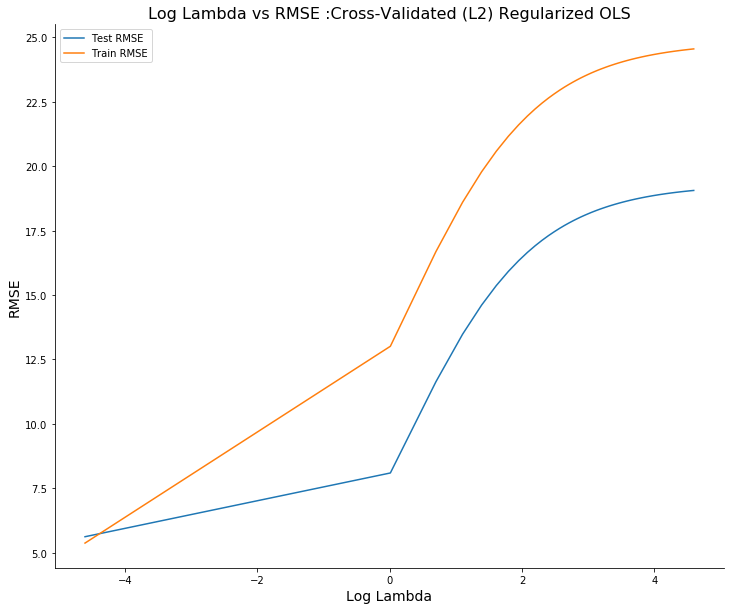

```python
#Create Error Plot
#Prepare the data
x= np.log(lambdas)

#Prepare the plot
plt.figure(figsize=(12,10))
plt.title('Log Lambda vs RMSE :Cross-Validated (L2) Regularized OLS', fontsize=16)
plt.xlabel('Log Lambda', fontsize=14)
plt.ylabel('RMSE', fontsize=14)

#Plot the data
plt.plot(x, mean_rmses_test, label = 'Test RMSE')
plt.plot(x, mean_rmses_train, label = 'Train RMSE')

#Remove spines on right and top
ax= plt.gca()
ax.spines['top'].set_visible(False)
ax.spines['right'].set_visible(False)

plt.legend(loc='best')
plt.show()
```

### (Showoff) Extra Credit 3: Lambda and coefficients

If you're feeling extra-special, create a parameter plot that shows how the different coefficient estimates change as a function of lambda. To make this graph intelligible, only include the *K* original F_s features in this plot

```python
#For all the parameters!
features = ['CRIM', 'ZN', 'INDUS', 'NOX', 'RM', 'AGE', 'DIS', 'RAD', 'TAX', 'PTRATIO', 'B', 'LSTAT']
numeric_df = boston_df[features]

coefs=[]
all_theta=[]

#Range of lambdas to test
lambdas = np.arange(0.01,100, 1)

for lambda_val in lambdas:
    _, _, theta = overfit_regularized_ols(numeric_df, features_list = features, standardize_data=True, add_interact=False,
                             shuffle_split_data= True, seed_val = 13579, split_pct=0.66,
                             R=0.01, maxIterations=10000, lamda_val= 0.01, verbose = False)
    coefs.append(theta)
    row = np.hstack((np.log(lambda_val),theta))
    all_theta.append(row)

all_theta = np.array(all_theta)

print(all_theta.shape)
```

```
(100, 13)
```

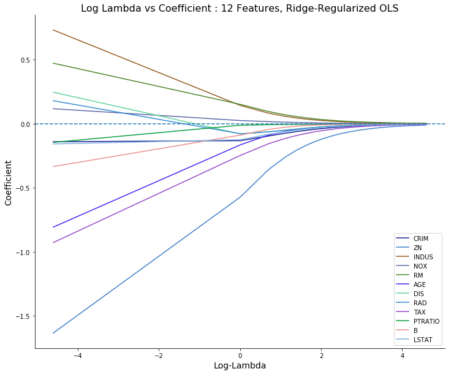

```python
#Create Error Plot
#Prepare the data
x = all_theta[0:,0]

#Labels
labs = features
#labs.insert(0,'INTERCEPT')

#Prepare the plot
plt.figure(figsize=(12,10))
plt.title('Log Lambda vs Coefficient : 12 Features, Ridge-Regularized OLS', fontsize=16)
plt.xlabel('Log-Lambda', fontsize=14)
plt.ylabel('Coefficient', fontsize=14)

#Plot the data
#Plot the data
for i in range(1,len(all_theta[0])):
    col = np.random.rand(3,1)
    plt.plot(x,all_theta[:,i], c= col,label= labs[i-1])

#Remove spines on right and top
ax= plt.gca()
ax.axhline(0, linestyle='--') #Horizontal 0 line
ax.spines['top'].set_visible(False)
ax.spines['right'].set_visible(False)

plt.legend(loc='best')
plt.show()
```

#### Let's make the graph intelligible

```python
#For all the parameters!
features=['CRIM', 'RM', 'TAX', 'LSTAT', 'PTRATIO']
numeric_df = boston_df[features]

coefs=[]
all_theta=[]

#Range of lambdas to test
lambdas = np.arange(0.01,100, 1)

for lambda_val in lambdas:
    _, _, theta = overfit_regularized_ols(numeric_df, features_list = features, standardize_data=True, add_interact=False,
                             shuffle_split_data= True, seed_val = 13579, split_pct=0.66,
                             R=0.01, maxIterations=10000, lamda_val= 0.01, verbose = False)
    coefs.append(theta)
    row = np.hstack((np.log(lambda_val),theta))
    all_theta.append(row)

all_theta = np.array(all_theta)

print(all_theta.shape)
```

```
(100, 6)
```

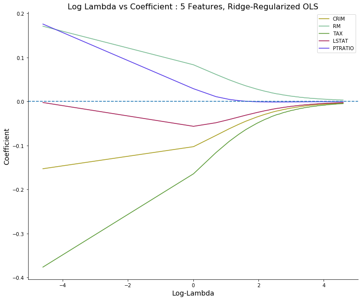

```python
#Create Error Plot
#Prepare the data
x = all_theta[0:,0]

#Labels
labs = features
#labs.insert(0,'INTERCEPT')

#Prepare the plot
plt.figure(figsize=(12,10))
plt.title('Log Lambda vs Coefficient : 5 Features, Ridge-Regularized OLS', fontsize=16)
plt.xlabel('Log-Lambda', fontsize=14)
plt.ylabel('Coefficient', fontsize=14)

#Plot the data
#Plot the data
for i in range(1,len(all_theta[0])):
    col = np.random.rand(3,1)
    plt.plot(x,all_theta[:,i], c= col,label= labs[i-1])

#Remove spines on right and top
ax= plt.gca()
ax.axhline(0, linestyle='--') #Horizontal 0 line
ax.spines['top'].set_visible(False)
ax.spines['right'].set_visible(False)

plt.legend(loc='best')
plt.show()
```

#### Let's make this the simplest possible model

```python
#For all the parameters!
features = ['CRIM', 'RM']
numeric_df = boston_df[features]

coefs=[]
all_theta=[]

#Range of lambdas to test
lambdas = np.arange(0.01,100, 1)

for lambda_val in lambdas:
    _, _, theta = overfit_regularized_ols(numeric_df, features_list = features, standardize_data=True, add_interact=False,
                             shuffle_split_data= True, seed_val = 13579, split_pct=0.66,
                             R=0.01, maxIterations=10000, lamda_val= 0.01, verbose = False)
    coefs.append(theta)
    row = np.hstack((np.log(lambda_val),theta))
    all_theta.append(row)

all_theta = np.array(all_theta)

print(all_theta.shape)
```

```
(100, 3)
```

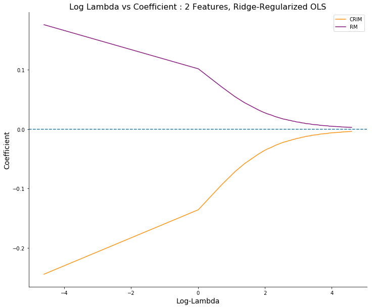

```python
#Create Error Plot
#Prepare the data
x = all_theta[0:,0]

#Labels
labs = features
#labs.insert(0,'INTERCEPT')

#Prepare the plot
plt.figure(figsize=(12,10))
plt.title('Log Lambda vs Coefficient : 2 Features, Ridge-Regularized OLS', fontsize=16)
plt.xlabel('Log-Lambda', fontsize=14)
plt.ylabel('Coefficient', fontsize=14)

#Plot the data
#Plot the data
for i in range(1,len(all_theta[0])):
    col = np.random.rand(3,1)
    plt.plot(x,all_theta[:,i], c= col,label= labs[i-1])

#Remove spines on right and top
ax= plt.gca()
ax.axhline(0, linestyle='--') #Horizontal 0 line
ax.spines['top'].set_visible(False)
ax.spines['right'].set_visible(False)

plt.legend(loc='best')
plt.show()
```